# Produção de gráficos com [R](http://developer.r-project.org/Logo/Rlogo-5.png)

## Tópico: Somatório de ondas harmônicas.

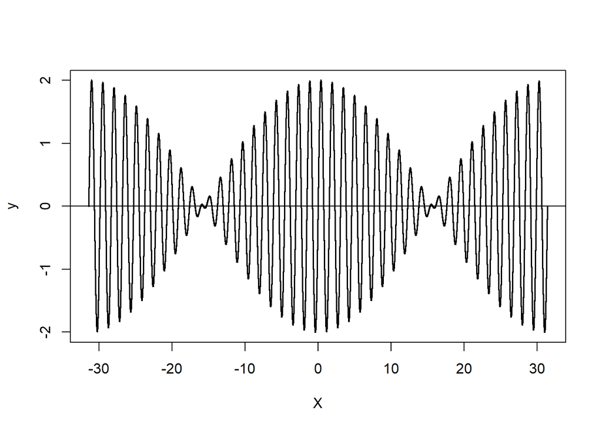

**Resumo:** Através deste trabalho mostro como trabalhar várias funções e como implementar técnicas rápidas e simples de programação, utilizando a linguaguem R, e ao mesmo tempo dando uma noção de como formar ondas harmônicas através de dados e ao final produzindo gráficos que mostram o comportamento destas ondas.

### Aprendendo programação em R e como pensar a teoria das ondas clássicas.

- Decidi fazer um passo a passo de como programar em R, para exibição de gráficos de ondas harmônicas. Para leitura deste artigo, não é necessário entender nenhum desses conceitos, mas toda informação prévia é muito bem utilizada.

### Gerando o gráfico mais simples

```r
# Atribuindo uma sequencia de 0 a 20
x = seq(0,20, 1)
# Listando a sequencia
x
```

```
##  [1]  0  1  2  3  4  5  6  7  8  9 10 11 12 13 14 15 16 17 18 19 20
```

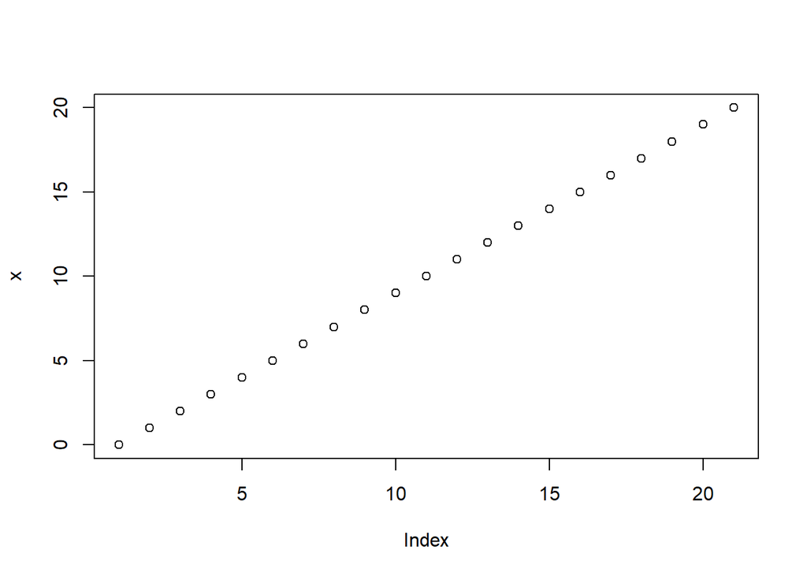

```r
# Grafico desta sequencia
plot(x)
```

- Como chamei a função plot com um array de 1 dimensão, o eixo horizontal assume seus valores como a sua posição (ordem) no array.
- A função plot lista a sequência. Com estes dois fundamentos vamos demonstrar como modelar segmentos de ondas.

### Gráfico de uma função de onda

- Já pulando alguns passos, vou fazer o próximo gráfico da função seno de x. Como as ondas tem caráter senoidal, o próximo gráfico já representa uma onda.
- Para melhorar a qualidade do gráfico, eu diminui o incremento da sequencia, ou seja, cada ponto será acrescido de 0.1, gerando mais pontos no gráfico, ou seja, vamos aumentar nossa sequencia x, para um conjunto maior, de 200 elementos. .

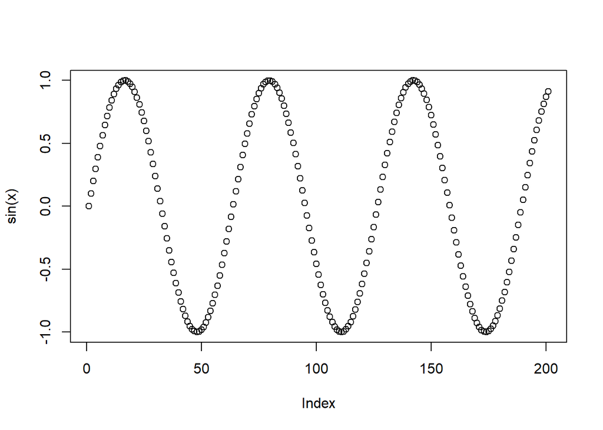

```r
x = seq(0,20, 0.1)
plot(sin(x))
```

- Para quem já tem conhecimento sobre ondas harmônicas e alguma coisa sobre R, por aqui já é suficiente para todo o desenvolvimento restante. Mas vamos no passo a passo.
- Vemos que o gráfico acima é equivalente a um pouco mais de três comprimentos de onda. Cada comprimento de onda (lambda) é o tamanho no eixo horizontal onde temos uma repetição.

### Gráfico com comprimentos de onda inteiros

- Iniciando uma sequencia com multiplos de PI
- O primeiro ajuste é iniciar e terminar a sequência de dados com múltiplos de Pi. Lembrando que `sin(n * PI) = 0`. Desta forma o gráfico fica com comprimentos de onda inteiros. Ainda vemos que o n representa a quantidade de ondas.

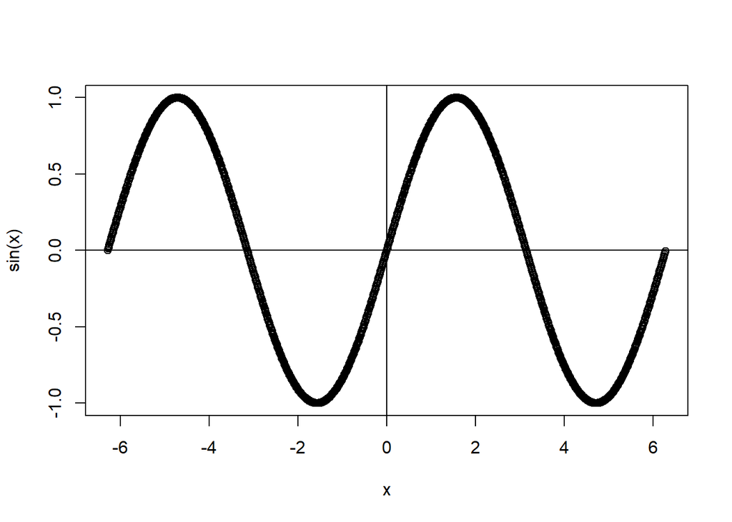

```r
x <- seq(-2*pi, 2*pi, 0.01)
plot( x , sin(x) )
abline(h=0)
abline(v=0)
```

- Aqui já temos um segmento de onda, podendo ser a representação da fotografia do movimento de uma corda.

### De ondas simples para ondas complexas

- Na primeira figura, vemos uma onda complexa com dois comprimentos de onda representados.
- A grande maioria dos sons que ouvimos, das ondas que enxergamos, que utilizamos nas comunicações, são ondas complexas, ou seja, possuem diversos comprimentos de onda e cada comprimento de onda é equivalente a uma frequencia. Estes comprimentos de onda, quando são múltiplos são chamados comprimentos de ondas harmônicos.
- Criando um vetor de 1 a 4 (diferentes frequencias/comprimentos de onda)

### Listando quatro ondas harmônicas no mesmo gráfico.

#### Script para montar vários harmônicos (ondas com frequencia múltiplas)

- Iniciando uma sequencia para representar dois comprimentos de onda.
- Iniciando um vetor com os números 1 a 4, que serão usados como multiplicadores.

```r
x <- seq(-2*pi, 2*pi, 0.01)
harm <- seq(1,4)
```

- inicializando vetores

```r
serie = c()
eixox = c()
cores = c()
```

- A cada loop, a série incrementa a série anterior.
- o conteudo da série é sen(x), sen(2x), …
- Matematicamente, o que multiplica o X, é a frequência angular (w), sendo f a frequência da onda.

$$w = 2\pi f$$

```r
for (i in 1:length(harm))
{
  serie = c( serie, sin(x*harm[i]) )
  eixox = c( eixox, x )
  cores = c( cores, rep(i, length(x)))
}
```

- Agora a série contém valores de todos os harmônicos em sequência. E as cores servem para diferenciar cada harmônico.
- Veja que o tamanho da série é quatro vezes o tamanho original de x, pois o loop realizou quatro voltas.
- Através da função length() podemos ver o tamanho do vetor x `length(x)` e do vetor série `length(serie)`

```
## [1] "length(x) =  1257 , length(serie) =  5028"
```

- Transformando o vetor em matriz XY.

```r
sobrepostos = matrix( c(eixox, serie), ncol=2)
dim(sobrepostos)
```

```
## [1] 5028    2
```

- Agora listando todas no mesmo gráfico.

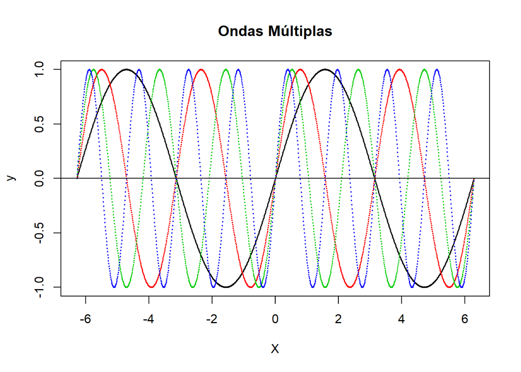

```r
title1 <- 'Ondas Múltiplas'

plot(sobrepostos, cex = 0.2, col=cores, xlab = 'X', ylab = 'y', main = title1)
abline(h=0)
```

### Onda resultante (unificar as quatro ondas)

```r
x <- seq(-2*pi, 2*pi, 0.01)
harm <- seq(1,4)

serie = sin(x*harm[1])
eixox = c(x)
cores = rep(1, length(x))

# ao invés de concatenar, agora vamos somá-los.

for (i in 2:length(harm))
{
  serie = serie + sin(x*harm[i])
}

ondaunica = matrix( c(eixox, serie), ncol=2)
```

- A onda única é resultado do somatório dos pontos em Y para cada posição do eixo x. Veja acima que o vetor eixox não sofre alteração de uma onda para a outra.
- Como estamos trabalhando com somatório, a onda resultante contém menos dados, pois ela é o agrupamento das posições do eixo x através do somatório das posições repetidas em Y.

```r
dim(ondaunica)
```

```
## [1] 1257    2
```

- Listando a onda resultante.

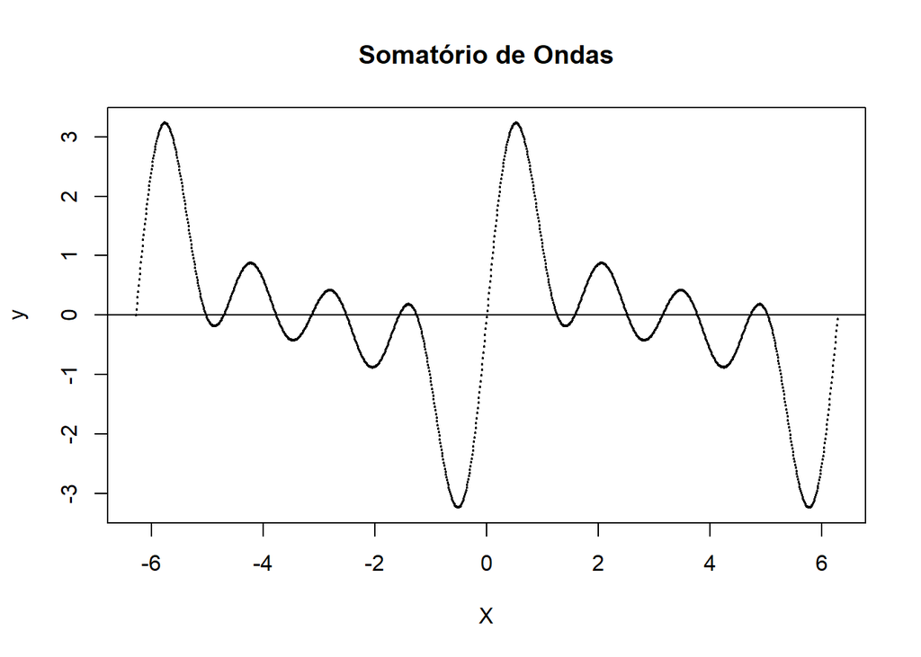

```r
title1 <- 'Somatório de Ondas'

plot(ondaunica, cex = 0.2, xlab = 'X', ylab = 'y', main = title1)
abline(h=0)
```

### Onda resultante mais ‘Natural’

- Na natureza, a produção de ondas com frequencias multiplas, que dão origem às notas harmonicas tem origem no fenomeno da reflexão. Por outro lado, e apesar da conservação de energia, a maioria das interações físicas possuem característica da resistência ao movimento, gerando assim uma diminuição da energia. Desta forma não é estranho pensar que a energia e por consequencia, a amplitude da onda seja menor a cada reflexão.
- Para implementar a amplitude, vamos atribuir pessos a cada uym dos harmônicos. Abaixo, o novo array `pesos`, iniciado como `c(100, 80, 80, 60)` mostra 100% para a primeira frequencia (a fundamental) e um leve decaimento até a quarta frequência.

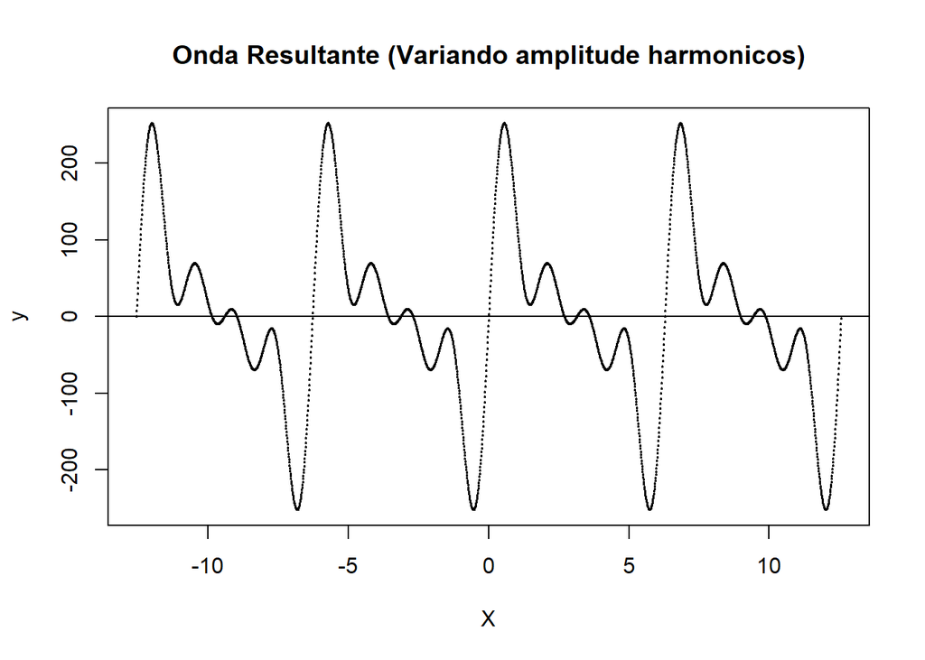

```r
x <- seq(-4*pi, 4*pi, 0.01)
harm <- seq(1,4)
pesos <- c(100, 80, 80, 60)

serie = pesos[1]*sin(x*harm[1])
eixox = c(x)
cores = rep(1, length(x))

# ao invés de concatenar, agora vamos somá-los.

for (i in 2:length(harm))
{
  serie = serie + pesos[i]*sin(x*harm[i])
}

ondaunica = matrix( c(eixox, serie), ncol=2)

title1 <- 'Onda Resultante (Variando amplitude harmonicos)'

plot(ondaunica, cex = 0.2, xlab = 'X', ylab = 'y', main = title1)
abline(h=0)
```

### Onda resultante de instrumentos musicais

- Os instrumentos musicais possuem uma arquitetura corporal e de ressonância que permite a formação de diferentes harmônicos, o que leva a um **timbre** diferente que permite a diferenciação auditiva. Uma mesma nota (frequencia fundamental), emitida por instrumentos diferentes são diferentes. Como se explica?
- O **timbre** é o próprio resultado da distribuição harmônica, e a nota que identificamos é a **frequência** da onda resultante. Como se pode ver abaixo, apesar de diferentes distribuições, o comprimento de onda se mantém semelhante ao comprimento de onda da nota mais grave, ou seja, a *frequência fundamental*.
- Primeiramente vamos aumentar o número de harmônicos sensíveis para 10 e modular os pesos destes harmônicos de forma diferente.
- Depois, estes pesos diferentes serão aplicados a cada uma das ondas antes de somá-las, trazendo assim a característica de amplitudes diferentes para cada múltiplo.

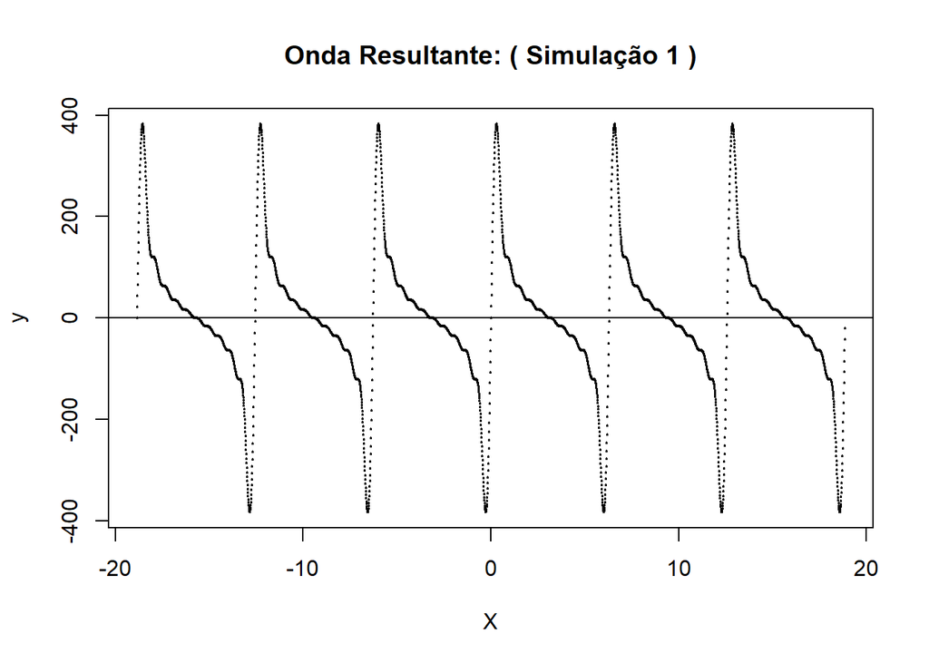

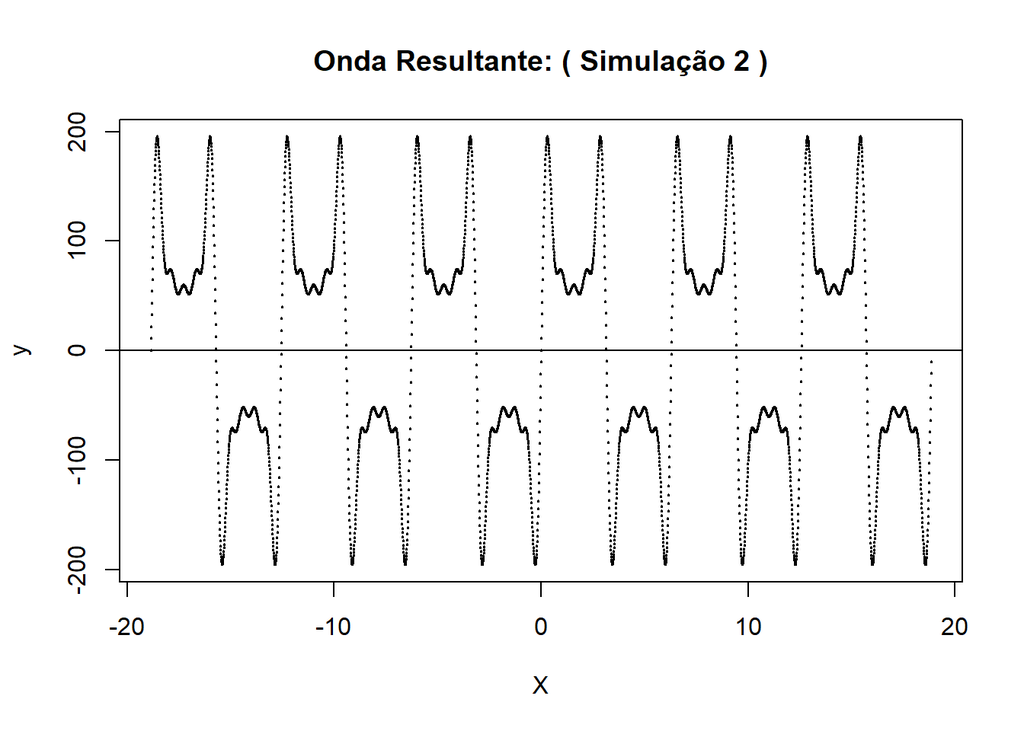

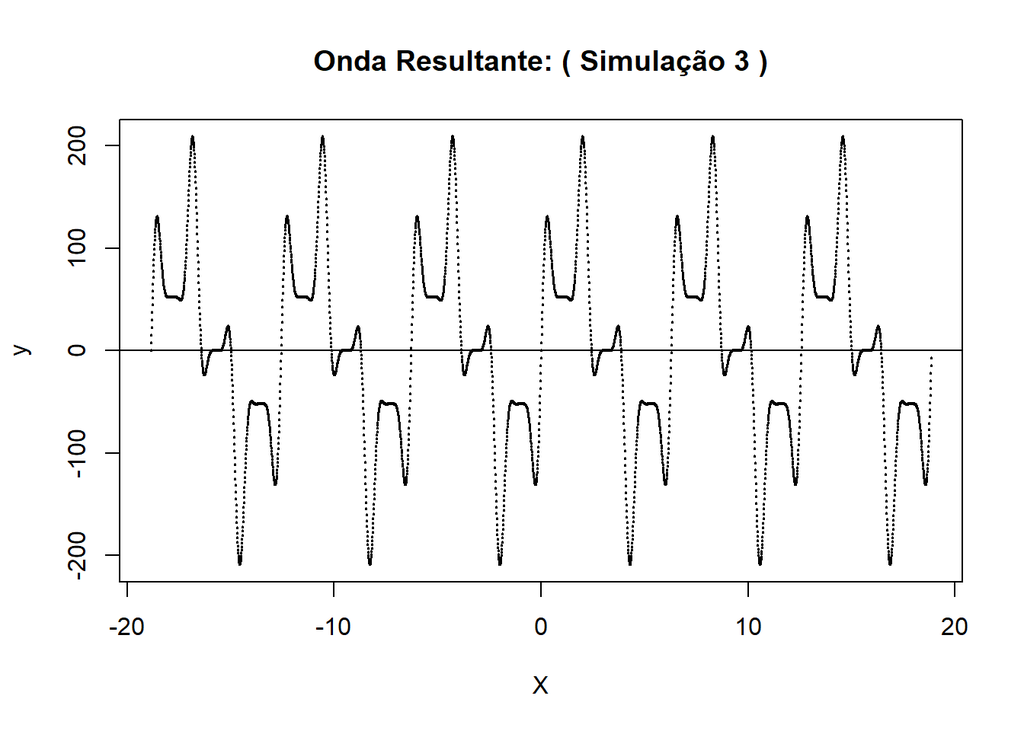

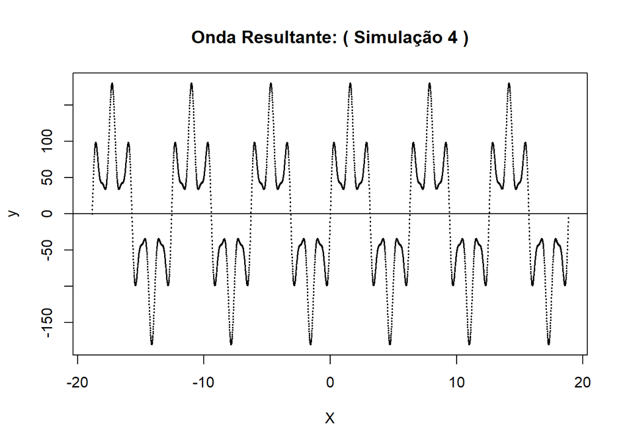

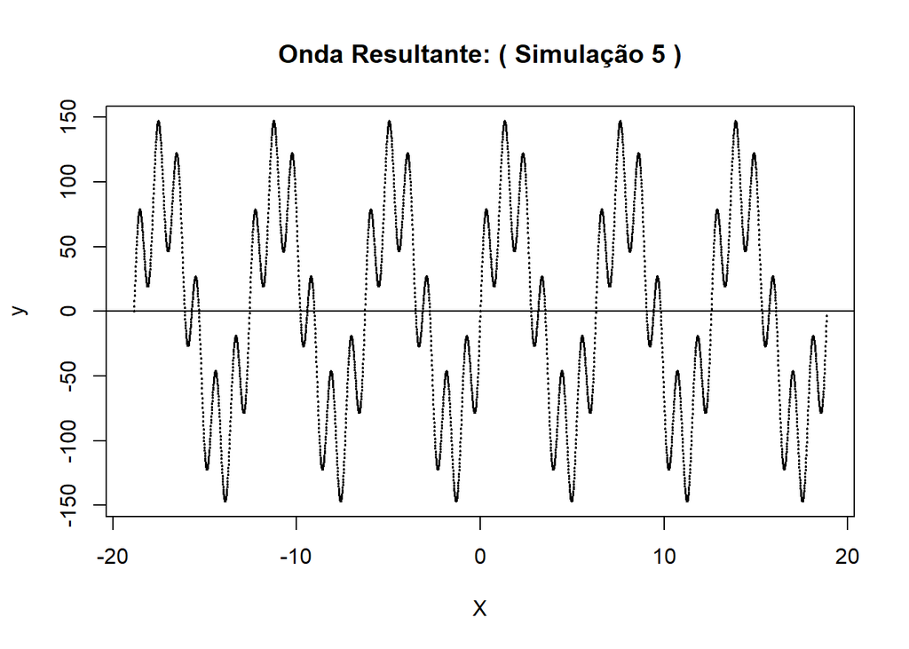

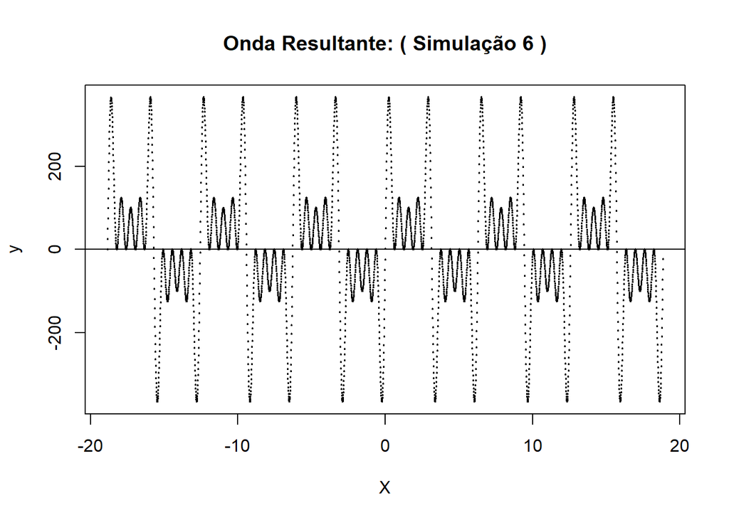

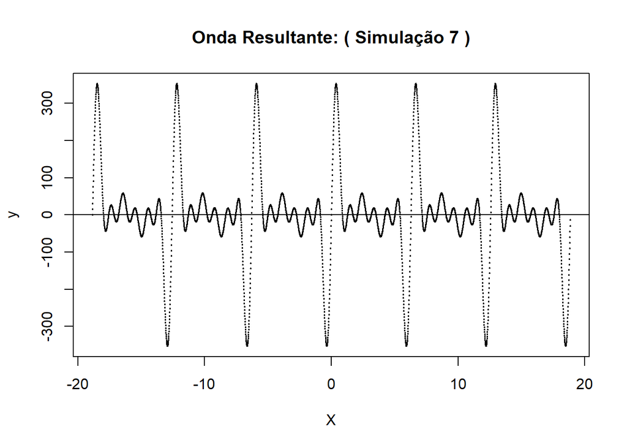

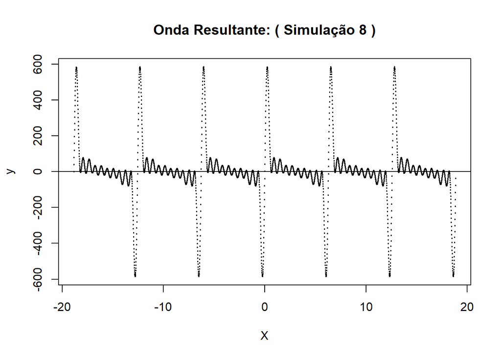

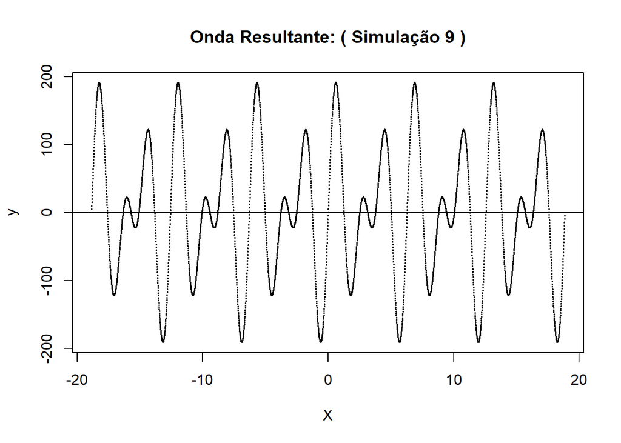

```r
x <- seq(-6*pi, 6*pi, 0.01)
harm <- seq(1,10)
pesos <- c(100, 90,  80,  70,  60,  50,  40,  30,  20,  10 )
pesos <- seq(100, 10, -10)

pesos2<- c(100,  0,  80,   0,  60,   0,  40,   0,  20,   0 )
pesos3<- c(100,  0,   0,  70,   0,   0,  40,   0,   0,  10 )
pesos4<- c(100,  0,   0,   0,  60,   0,   0,   0,  20,   0 )
pesos5<- c(100,  0,   0,   0,   0,  50,   0,   0,   0,   0 )
pesos6<- c(100,  0, 100,   0, 100,   0, 100,   0, 100,   0 )
#Instrumentos de sopro com comportamento anômalo, com pedal no terceiro ou quinto harmonico
pesos7<- c( 50, 60, 100,  90,  70,  60,   0,   0,   0,   0 )
pesos8<- c( 60, 70,  80,  90, 100,  90, 80,  70,   60,  50 )
pesos9<- c( 0,100, 100, 0,   0, 0,  0,  0,   0,  0 )

for (instru in 1:9) {

    # Em cada loop, assume um tipo de distribuição de pesos de cada harmônico
    if(instru==2) {pesos <- pesos2}
    if(instru==3) {pesos <- pesos3}
    if(instru==4) {pesos <- pesos4}
    if(instru==5) {pesos <- pesos5}
    if(instru==6) {pesos <- pesos6}
    if(instru==7) {pesos <- pesos7}
    if(instru==8) {pesos <- pesos8}
    if(instru==9) {pesos <- pesos9}


    serie = pesos[1]*sin(x*harm[1])
    eixox = c(x)
    cores = rep(1, length(x))

    # ao invés de concatenar, agora vamos somá-los.

    for (i in 2:length(harm))
    {
      serie = serie + pesos[i]*sin(x*harm[i])
    }

    ondaunica = matrix( c(eixox, serie), ncol=2)


    title1 <- paste('Onda Resultante: ( Simulação' , instru , ')' )

    plot(ondaunica, cex = 0.2, xlab = 'X', ylab = 'y', main = title1)
    abline(h=0)
}
```

### Batimento

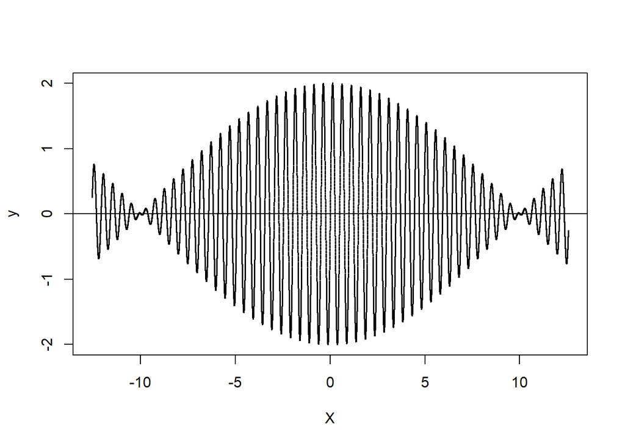

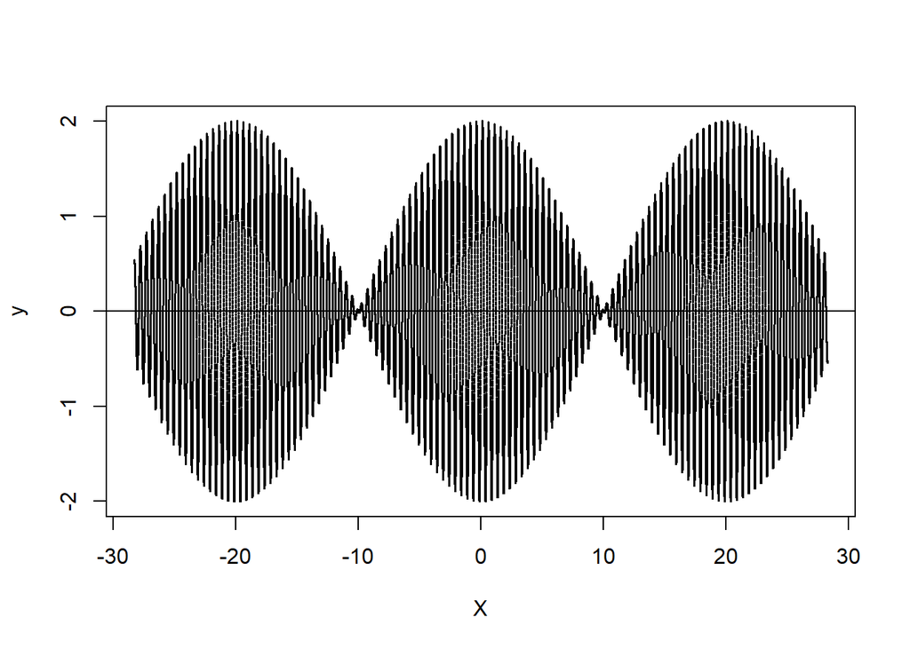

```r
for(nBat in c(2,3,3) )
{
  x <- seq(-(nBat^2)*pi , (nBat^2)*pi, 0.001)
  harm <- c(4*pi,4.1*pi)

  serie = sin(x*harm[1])
  eixox = c(x)
  cores = rep(1, length(x))

  for (i in 2:length(harm))
  {
    serie = serie + sin(x*harm[i])
  }

  ondaunica = matrix( c(eixox, serie), ncol=2)

  title1 <- ''

  plot(ondaunica, cex = 0.2, xlab = 'X', ylab = 'y', main = title1)
  abline(h=0)
}
```

[figure not shown]

```r
# Ultimo gráfico, traçar a curva do batimento
serie = serie + sin(x* 0.1 * pi)

plot(ondaunica, cex = 0.2, xlab = 'X', ylab = 'y', main = title1)
```